# 2nd submission

### Predict if the server will be hacked or not

All the countries across the globe have adapted to means of digital payments and with the increased volume of digital payments, hacking has become a pretty common event wherein the hacker can try to hack your details just with your phone number linked to bank account. However there is data with some anonymized variables based on which one can predict that hack is going to happen.

```
                My work is to build a  predictive model which can identify the pattern in these variables and suggest that a hack is going to happen so that the cyber security can somehow stop  it before it actually happens.

                     Predict the column: Malicious_offence[1: Yes(hack can happen), 0 (hack may not happen)
```

### Import the packages

```python
import os
import numpy as np
import pandas as pd
import graphviz
from sklearn import preprocessing
from sklearn.impute import SimpleImputer
from sklearn.experimental import enable_iterative_imputer
from sklearn.impute import IterativeImputer

from sklearn.compose import ColumnTransformer
from sklearn.model_selection import RandomizedSearchCV, GridSearchCV, cross_val_score, StratifiedKFold
from sklearn.metrics import roc_auc_score
from sklearn.model_selection import StratifiedKFold

from sklearn.preprocessing import StandardScaler
from sklearn.preprocessing import OneHotEncoder
from sklearn.model_selection import train_test_split
from sklearn.pipeline import Pipeline
from sklearn.metrics import accuracy_score, classification_report, recall_score, precision_score,confusion_matrix, cohen_kappa_score, f1_score

from sklearn import tree
from sklearn.tree import DecisionTreeClassifier
from sklearn.metrics import auc,roc_curve
from sklearn.metrics import roc_auc_score
from sklearn.linear_model import LogisticRegression

from sklearn.metrics import confusion_matrix
from xgboost import XGBClassifier
import matplotlib.pyplot as plt
import seaborn as sns
import warnings
warnings.filterwarnings('ignore')
```

#### Defining a function for performance analysis of error metric

```python
def classificationMetrics(data_type,act,prd):
    print("\n\nClassification Metrics for data-set type : ", data_type)
    myAccuracy=accuracy_score(act,prd)
    myPrecision=precision_score(act,prd)
    myRecall=recall_score(act,prd)
    myF1=f1_score(act,prd)
    roc_auc=roc_auc_score(act,prd)
    cnf=confusion_matrix(act,prd)
    myKappa=cohen_kappa_score(act,prd)
    print("accuracy : ",myAccuracy)
    print("precision : ",myPrecision)
    print("recall : ",myRecall)
    print("F1-score : ",myF1)
    print("myKappa : ",myKappa)
    print("roc_auc_score : ",roc_auc)
    print("ConfusionMetrix :\n", cnf)
```

### Read the data

```python
train=pd.read_csv("Train.csv",parse_dates=["DATE"]).sort_values(["DATE"])
test=pd.read_csv("Test.csv",parse_dates=["DATE"])
train.tail()
```

|  | INCIDENT_ID | DATE | X_1 | X_2 | X_3 | X_4 | X_5 | X_6 | X_7 | X_8 | X_9 | X_10 | X_11 | X_12 | X_13 | X_14 | X_15 | MULTIPLE_OFFENSE |
| --- | --- | --- | --- | --- | --- | --- | --- | --- | --- | --- | --- | --- | --- | --- | --- | --- | --- | --- |
| 11299 | CR_196992 | 2018-12-28 | 0 | 38 | 38 | 10 | 3 | 8 | 3 | 1 | 5 | 1 | 290 | 1.0 | 1 | 0 | 34 | 1 |
| 5055 | CR_198746 | 2018-12-29 | 0 | 51 | 50 | 7 | 3 | 8 | 3 | 1 | 6 | 1 | 218 | 0.0 | 72 | 142 | 48 | 1 |
| 20479 | CR_197301 | 2018-12-29 | 0 | 43 | 43 | 9 | 0 | 4 | 2 | 1 | 6 | 1 | 316 | 1.0 | 114 | 29 | 34 | 1 |
| 4238 | CR_195253 | 2018-12-30 | 0 | 26 | 27 | 9 | 0 | 3 | 5 | 1 | 2 | 1 | 316 | 1.0 | 103 | 62 | 34 | 1 |
| 14034 | CR_197007 | 2018-12-31 | 0 | 38 | 38 | 10 | 3 | 6 | 4 | 0 | 5 | 1 | 249 | 1.0 | 103 | 29 | 34 | 1 |

```python
train.head(2)
```

|  | INCIDENT_ID | DATE | X_1 | X_2 | X_3 | X_4 | X_5 | X_6 | X_7 | X_8 | X_9 | X_10 | X_11 | X_12 | X_13 | X_14 | X_15 | MULTIPLE_OFFENSE |
| --- | --- | --- | --- | --- | --- | --- | --- | --- | --- | --- | --- | --- | --- | --- | --- | --- | --- | --- |
| 19022 | CR_1141 | 1991-01-01 | 0 | 22 | 22 | 7 | 3 | 8 | 3 | 7 | 2 | 2 | 0 | 2.0 | 72 | 142 | 34 | 1 |
| 13104 | CR_2248 | 1991-01-02 | 0 | 33 | 32 | 2 | 1 | 7 | 1 | 1 | 6 | 1 | 249 | 1.0 | 72 | 142 | 34 | 1 |

```python
test.tail()
```

|  | INCIDENT_ID | DATE | X_1 | X_2 | X_3 | X_4 | X_5 | X_6 | X_7 | X_8 | X_9 | X_10 | X_11 | X_12 | X_13 | X_14 | X_15 |
| --- | --- | --- | --- | --- | --- | --- | --- | --- | --- | --- | --- | --- | --- | --- | --- | --- | --- |
| 15898 | CR_44468 | 1997-11-28 | 1 | 22 | 22 | 7 | 3 | 15 | 10 | 0 | 5 | 1 | 174 | 0.0 | 72 | 29 | 43 |
| 15899 | CR_158460 | 2012-06-09 | 0 | 35 | 30 | 3 | 5 | 1 | 0 | 2 | 3 | 2 | 0 | 2.0 | 72 | 93 | 34 |
| 15900 | CR_115946 | 2006-04-22 | 0 | 26 | 27 | 9 | 0 | 6 | 4 | 2 | 6 | 1 | 0 | 1.0 | 72 | 62 | 34 |
| 15901 | CR_137663 | 2009-04-03 | 0 | 21 | 23 | 4 | 1 | 2 | 7 | 1 | 6 | 2 | 249 | 2.0 | 92 | 62 | 34 |
| 15902 | CR_33545 | 1996-04-24 | 0 | 4 | 4 | 6 | 5 | 4 | 2 | 5 | 6 | 1 | 249 | 1.0 | 72 | 29 | 34 |

### Exploratory data analysis

```python
print("train shape:",train.shape)
print("test shape:",test.shape)
```

```
train shape: (23856, 18)
test shape: (15903, 17)
```

```python
train.DATE.min(),train.DATE.max()
```

```
(Timestamp('1991-01-01 00:00:00'), Timestamp('2018-12-31 00:00:00'))
```

```python
test.DATE.min(),test.DATE.max()
```

```
(Timestamp('1991-01-02 00:00:00'), Timestamp('2018-12-28 00:00:00'))
```

```python
train.columns
```

```
Index(['INCIDENT_ID', 'DATE', 'X_1', 'X_2', 'X_3', 'X_4', 'X_5', 'X_6', 'X_7',
       'X_8', 'X_9', 'X_10', 'X_11', 'X_12', 'X_13', 'X_14', 'X_15',
       'MULTIPLE_OFFENSE'],
      dtype='object')
```

#### Understanding the correlation between variables

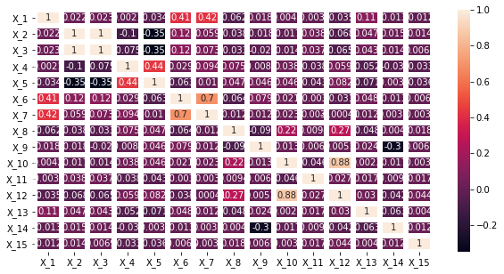

```python
plt.figure(figsize=(10,5))
corr = train[['X_1', 'X_2', 'X_3', 'X_4', 'X_5', 'X_6', 'X_7',
       'X_8', 'X_9', 'X_10', 'X_11', 'X_12', 'X_13', 'X_14', 'X_15',]].corr()
ax = sns.heatmap(corr,annot =True, linewidth = 5, cbar = True)
```

#### Finding missing values

```python
train.isnull().sum(),test.isnull().sum()
```

```
(INCIDENT_ID           0
 DATE                  0
 X_1                   0
 X_2                   0
 X_3                   0
 X_4                   0
 X_5                   0
 X_6                   0
 X_7                   0
 X_8                   0
 X_9                   0
 X_10                  0
 X_11                  0
 X_12                182
 X_13                  0
 X_14                  0
 X_15                  0
 MULTIPLE_OFFENSE      0
 dtype: int64,
 INCIDENT_ID      0
 DATE             0
 X_1              0
 X_2              0
 X_3              0
 X_4              0
 X_5              0
 X_6              0
 X_7              0
 X_8              0
 X_9              0
 X_10             0
 X_11             0
 X_12           127
 X_13             0
 X_14             0
 X_15             0
 dtype: int64)
```

```python
train["X_3"].nunique(),test["X_3"].nunique()
```

```
(52, 52)
```

#### Its a imbalanced data set

```python
train["MULTIPLE_OFFENSE"].value_counts()
```

```
1    22788
0     1068
Name: MULTIPLE_OFFENSE, dtype: int64
```

```python
train.drop(["INCIDENT_ID","DATE"],axis="columns",inplace=True)
```

### Finding variables which could be catagorical

```python
cat= []
for i in train.columns:
    if train[i].dtype =='object' or len(np.unique(train[i]))<=20 :
        cat.append(i)
        print("{} : {} levels : {} ".format(i,len(np.unique(train[i])),np.unique(train[i])))
```

```
X_1 : 8 levels : [0 1 2 3 4 5 6 7]
X_4 : 10 levels : [ 0  1  2  3  4  5  6  7  9 10]
X_5 : 5 levels : [0 1 2 3 5]
X_6 : 19 levels : [ 1  2  3  4  5  6  7  8  9 10 11 12 13 14 15 16 17 18 19]
X_7 : 19 levels : [ 0  1  2  3  4  5  6  7  8  9 10 11 12 13 14 15 16 17 18]
X_9 : 7 levels : [0 1 2 3 4 5 6]
MULTIPLE_OFFENSE : 2 levels : [0 1]
```

we can understand that Incident_id is unique, we can drop or make it as an index, assuming below 20 levels as catagorical columns

```python
test["X_15"].isin(train.X_15).value_counts()
test["X_10"].isin(train.X_10).value_counts()
# treat X_10 ,X_15 as numerical
# X_1,X_4,X_5,X_6,X_7,X_9 are catagorical
```

```
True     15900
False        3
Name: X_10, dtype: int64
```

```python
cat
```

```
['X_1', 'X_4', 'X_5', 'X_6', 'X_7', 'X_9', 'MULTIPLE_OFFENSE']
```

```python
num=list(train.columns.difference(cat))
num
```

```
['X_10', 'X_11', 'X_12', 'X_13', 'X_14', 'X_15', 'X_2', 'X_3', 'X_8']
```

```python
cat.pop(-1)
```

```
'MULTIPLE_OFFENSE'
```

```python
train[cat]=train[cat].astype("category")
train[cat].columns
```

```
Index(['X_1', 'X_4', 'X_5', 'X_6', 'X_7', 'X_9'], dtype='object')
```

```python
train.info()
```

```
<class 'pandas.core.frame.DataFrame'>
Int64Index: 23856 entries, 19022 to 14034
Data columns (total 16 columns):
X_1                 23856 non-null category
X_2                 23856 non-null int64
X_3                 23856 non-null int64
X_4                 23856 non-null category
X_5                 23856 non-null category
X_6                 23856 non-null category
X_7                 23856 non-null category
X_8                 23856 non-null int64
X_9                 23856 non-null category
X_10                23856 non-null int64
X_11                23856 non-null int64
X_12                23674 non-null float64
X_13                23856 non-null int64
X_14                23856 non-null int64
X_15                23856 non-null int64
MULTIPLE_OFFENSE    23856 non-null int64
dtypes: category(6), float64(1), int64(9)
memory usage: 2.1 MB
```

```python
train.index.nunique(),train.shape
```

```
(23856, (23856, 16))
```

```python
train[train["X_12"]==90].index[0]
```

```
2351
```

```python
train["X_12"].mean()
```

```
0.974064374419194
```

```python
a=train.drop(train[train["X_12"]==90].index[0])["X_12"]
```

### Checking the presence of outliers

```python
train.describe()
```

|  | X_2 | X_3 | X_8 | X_10 | X_11 | X_12 | X_13 | X_14 | X_15 | MULTIPLE_OFFENSE |
| --- | --- | --- | --- | --- | --- | --- | --- | --- | --- | --- |
| count | 23856.000000 | 23856.000000 | 23856.000000 | 23856.000000 | 23856.000000 | 23674.000000 | 23856.000000 | 23856.000000 | 23856.000000 | 23856.000000 |
| mean | 24.791206 | 24.637450 | 0.972460 | 1.244802 | 206.954519 | 0.974064 | 85.237383 | 72.674296 | 33.464747 | 0.955231 |
| std | 15.240231 | 15.135093 | 1.453144 | 1.119301 | 93.033348 | 1.167725 | 27.597226 | 43.297320 | 8.386834 | 0.206800 |
| min | 0.000000 | 0.000000 | 0.000000 | 1.000000 | 0.000000 | 0.000000 | 0.000000 | 0.000000 | 0.000000 | 0.000000 |
| 25% | 7.000000 | 8.000000 | 0.000000 | 1.000000 | 174.000000 | 1.000000 | 72.000000 | 29.000000 | 34.000000 | 1.000000 |
| 50% | 24.000000 | 24.000000 | 1.000000 | 1.000000 | 249.000000 | 1.000000 | 98.000000 | 62.000000 | 34.000000 | 1.000000 |
| 75% | 36.000000 | 35.000000 | 1.000000 | 1.000000 | 249.000000 | 1.000000 | 103.000000 | 107.000000 | 34.000000 | 1.000000 |
| max | 52.000000 | 52.000000 | 99.000000 | 90.000000 | 332.000000 | 90.000000 | 116.000000 | 142.000000 | 50.000000 | 1.000000 |

```python
import plotly.offline as pyo
import plotly.graph_objs as go
data = [
    go.Box(
        y=a,
        boxpoints='all',# display the original data points
        jitter=0.3,      # spread them out so they all appear
        pointpos=-1.8  )]
fig=go.Figure(data)
fig.show()
```

[interactive chart not shown]

#### There are many outliers in X_12 so better to impute with median instaed of mean

#### Train test split(considering 80% as train data and 20% as test data)

```python
X, y = train.loc[:,train.columns!='MULTIPLE_OFFENSE'], train.loc[:,'MULTIPLE_OFFENSE']

X_train, X_test, y_train, y_test = train_test_split(X, y, test_size=0.2,stratify=y ,random_state=3)
```

### Building a simple logistic regression model

```python
imp=SimpleImputer(strategy='median')# imputing with median
imp.fit(X_train[num])
scaler=StandardScaler()# doing standardization of all the numeric columns
scaler.fit(X_train[num])
X_train[num]=imp.transform(X_train[num])
X_test[num]=imp.transform(X_test[num])
X_train[num]=scaler.transform(X_train[num])
X_test[num]=scaler.transform(X_test[num])
X_train = pd.get_dummies(columns=cat,data=X_train,drop_first=True)#converting catagorical variables to numeric dummy variables
X_test = pd.get_dummies(columns=cat,data=X_test,drop_first=True)
clf = LogisticRegression()
clf = clf.fit(X_train, y_train)
traine_pred = clf.predict(X_train)
teste_pred = clf.predict(X_test)
classificationMetrics("Train", y_train,traine_pred)
classificationMetrics("Test", y_test, teste_pred)
```

```
Classification Metrics for data-set type :  Train
accuracy :  0.9566652693355691
precision :  0.9595943590556172
recall :  0.9965990126165661
F1-score :  0.9777466835293168
myKappa :  0.16589815866723556
roc_auc_score :  0.5504072346455197
ConfusionMetrix :
 [[   89   765]
 [   62 18168]]


Classification Metrics for data-set type :  Test
accuracy :  0.9557837384744342
precision :  0.9596109113977586
recall :  0.9956121105748135
F1-score :  0.9772800689135351
myKappa :  0.1664801324503311
roc_auc_score :  0.5515443730444161
ConfusionMetrix :
 [[  23  191]
 [  20 4538]]
```

### Building descision tree for getting higher performances along with hyperparameter tuning

```python
param_grid = {'criterion': ['entropy', 'gini'], 'max_depth': [6,8,10,12],
                 "min_samples_split": [2, 10, 20],"min_samples_leaf": [1, 5, 10]}

#Enter the code here
dt = tree.DecisionTreeClassifier(random_state=3)
clf2 = GridSearchCV(dt, param_grid, cv = 5,n_jobs=-1)
clf2.fit(X_train, y_train)
traine_pred = clf2.predict(X_train)
teste_pred = clf2.predict(X_test)
classificationMetrics("Train", y_train,traine_pred)
classificationMetrics("Test", y_test, teste_pred)
```

```
Classification Metrics for data-set type :  Train
accuracy :  0.9992664011737581
precision :  0.9998353638459005
recall :  0.9993965990126166
F1-score :  0.9996159332821244
myKappa :  0.9914574338639834
roc_auc_score :  0.9979418592252778
ConfusionMetrix :
 [[  851     3]
 [   11 18219]]


Classification Metrics for data-set type :  Test
accuracy :  0.9985331098072087
precision :  0.9995609220636663
recall :  0.9989030276437034
F1-score :  0.999231866564249
myKappa :  0.9829906062358951
roc_auc_score :  0.9947786166255901
ConfusionMetrix :
 [[ 212    2]
 [   5 4553]]
```

#### First Predictions on the test data

```python
index=test.INCIDENT_ID
test.drop(["INCIDENT_ID","DATE"],axis="columns",inplace=True)
```

```python
test[cat]=test[cat].astype("category")
test[num]=imp.transform(test[num])
test[num]=scaler.transform(test[num])
test = pd.get_dummies(columns=cat,data=test,drop_first=True)
```

```python
predictions = clf2.predict(test)
```

```python
submission=pd.DataFrame(data=index)
submission["MULTIPLE_OFFENSE"]=predictions
submission.set_index("INCIDENT_ID",inplace=True)
```

```python
submission.to_csv("first _predictions.csv")
```

##### Calculating feature importance

```python
features = X_train.columns
importances =clf2.best_estimator_.feature_importances_
indices = np.argsort(importances)[::-1] # np.argsort returns the indices that would sort an array.
pd.DataFrame([X_train.columns[indices],np.sort(importances)[::-1]])
```

|  | 0 | 1 | 2 | 3 | 4 | 5 | 6 | 7 | 8 | 9 | ... | 61 | 62 | 63 | 64 | 65 | 66 | 67 | 68 | 69 | 70 |
| --- | --- | --- | --- | --- | --- | --- | --- | --- | --- | --- | --- | --- | --- | --- | --- | --- | --- | --- | --- | --- | --- |
| 0 | X_10 | X_11 | X_15 | X_12 | X_4_2 | X_2 | X_6_9 | X_9_5 | X_14 | X_9_6 | ... | X_6_13 | X_6_12 | X_6_11 | X_6_10 | X_7_15 | X_7_16 | X_6_7 | X_6_6 | X_6_5 | X_6_8 |
| 1 | 0.365707 | 0.294125 | 0.177938 | 0.152629 | 0.0040676 | 0.00220765 | 0.00139874 | 0.000872747 | 0.000573708 | 0.000480399 | ... | 0 | 0 | 0 | 0 | 0 | 0 | 0 | 0 | 0 | 0 |

2 rows × 71 columns

#### from the above we can observe that most of the important attributes are only numerical.

#### let us assume all the attributes as numerical and build models

##### Treating all variables as numeric variables and build descision Tree

```python
tn=pd.read_csv("train.csv",parse_dates=["DATE"])
```

```python
tn.drop(["INCIDENT_ID","DATE"],inplace=True,axis=1)
```

```python
X, y = tn.loc[:,tn.columns!='MULTIPLE_OFFENSE'], tn.loc[:,'MULTIPLE_OFFENSE']

X_train, X_test, y_train, y_test = train_test_split(X, y, test_size=0.2,stratify=y ,random_state=3)
```

```python
imp=SimpleImputer(strategy='median')
imp.fit(X_train)
scaler=StandardScaler()
scaler.fit(X_train)
X_train=imp.transform(X_train)
X_test=imp.transform(X_test)
X_train=scaler.transform(X_train)
X_test=scaler.transform(X_test)
```

```python
clf2.fit(X_train, y_train)
traine_pred = clf2.predict(X_train)
teste_pred = clf2.predict(X_test)
classificationMetrics("Train", y_train,traine_pred)
classificationMetrics("Test", y_test, teste_pred)
```

```
Classification Metrics for data-set type :  Train
accuracy :  1.0
precision :  1.0
recall :  1.0
F1-score :  1.0
myKappa :  1.0
roc_auc_score :  1.0
ConfusionMetrix :
 [[  854     0]
 [    0 18230]]


Classification Metrics for data-set type :  Test
accuracy :  0.9993713327745181
precision :  0.9995613073042334
recall :  0.9997806055287407
F1-score :  0.9996709443896019
myKappa :  0.9926451851547409
roc_auc_score :  0.9952174055681088
ConfusionMetrix :
 [[ 212    2]
 [   1 4557]]
```

##### We can observe that we got better results while considering as numeric variables so let us find the important variables and see the performance so that we can reduce computational complexity

```python
clf2.best_estimator_.feature_importances_
```

```
array([0.        , 0.        , 0.00054751, 0.00071738, 0.        ,
       0.        , 0.        , 0.00120076, 0.0011726 , 0.35144486,
       0.30914845, 0.14684399, 0.        , 0.        , 0.18892445])
```

```python
features = tn.columns
importances = clf2.best_estimator_.feature_importances_
indices = np.argsort(importances)[::-1] # np.argsort returns the indices that would sort an array.
pd.DataFrame([train.columns[indices],np.sort(importances)[::-1]])
```

|  | 0 | 1 | 2 | 3 | 4 | 5 | 6 | 7 | 8 | 9 | 10 | 11 | 12 | 13 | 14 |
| --- | --- | --- | --- | --- | --- | --- | --- | --- | --- | --- | --- | --- | --- | --- | --- |
| 0 | X_10 | X_11 | X_15 | X_12 | X_8 | X_9 | X_4 | X_3 | X_14 | X_13 | X_7 | X_6 | X_5 | X_2 | X_1 |
| 1 | 0.351445 | 0.309148 | 0.188924 | 0.146844 | 0.00120076 | 0.0011726 | 0.000717382 | 0.000547508 | 0 | 0 | 0 | 0 | 0 | 0 | 0 |

```python
tn["X_7"].nunique(),tn["X_8"].nunique()
```

```
(19, 24)
```

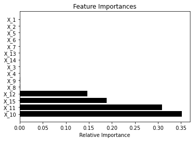

```python
plt.title('Feature Importances')
plt.barh(range(len(indices)), importances[indices], color='black')
plt.yticks(range(len(indices)), [features[i] for i in indices])
plt.xlabel('Relative Importance')
plt.show()
```

### let us build one more descision tree considering only important variables "X_8",'X_10', 'X_11', 'X_12', 'X_15'

```python
fea=tn.copy()
fea.drop(["X_1","X_2","X_6","X_9","X_4","X_3","X_5","X_7","X_13","X_14"],axis="columns",inplace=True)
```

```python
fea.nunique()
```

```
X_8                  24
X_10                 24
X_11                133
X_12                 23
X_15                 28
MULTIPLE_OFFENSE      2
dtype: int64
```

```python
fea.isnull().sum()
```

```
X_8                   0
X_10                  0
X_11                  0
X_12                182
X_15                  0
MULTIPLE_OFFENSE      0
dtype: int64
```

```python
nu=["X_8",'X_10', 'X_11', 'X_12', 'X_15']
```

```python
X, y = fea.loc[:,fea.columns!='MULTIPLE_OFFENSE'], fea.loc[:,'MULTIPLE_OFFENSE']

X_train, X_test, y_train, y_test = train_test_split(X, y, test_size=0.2,stratify=y ,random_state=3)
```

```python
numeric_transformer = Pipeline(steps=[
    ('imputer', SimpleImputer(strategy='median')),
    ('scaler', StandardScaler())
    ])
preprocessor = ColumnTransformer(
    transformers=[
        ('num', numeric_transformer, nu)])
```

```python
preprocessor
```

```
ColumnTransformer(n_jobs=None, remainder='drop', sparse_threshold=0.3,
                  transformer_weights=None,
                  transformers=[('num',
                                 Pipeline(memory=None,
                                          steps=[('imputer',
                                                  SimpleImputer(add_indicator=False,
                                                                copy=True,
                                                                fill_value=None,
                                                                missing_values=nan,
                                                                strategy='median',
                                                                verbose=0)),
                                                 ('scaler',
                                                  StandardScaler(copy=True,
                                                                 with_mean=True,
                                                                 with_std=True))],
                                          verbose=False),
                                 ['X_8', 'X_10', 'X_11', 'X_12', 'X_15'])],
                  verbose=False)
```

```python
%%time
clf_dt = Pipeline(steps=[('preprocessor', preprocessor),
                      ('classifier', DecisionTreeClassifier(random_state=3))])

param_grid = {'classifier__criterion': ['entropy', 'gini'], 'classifier__max_depth': [6,8,10,12],
                 "classifier__min_samples_split": [2, 10, 20],"classifier__min_samples_leaf": [1, 5, 10],
                    }

dt_grid = GridSearchCV(clf_dt, param_grid=param_grid, cv=5,n_jobs=-1)

dt_grid.fit(X_train,y_train)
```

```
Wall time: 6.84 s
```

```
GridSearchCV(cv=5, error_score=nan,
             estimator=Pipeline(memory=None,
                                steps=[('preprocessor',
                                        ColumnTransformer(n_jobs=None,
                                                          remainder='drop',
                                                          sparse_threshold=0.3,
                                                          transformer_weights=None,
                                                          transformers=[('num',
                                                                         Pipeline(memory=None,
                                                                                  steps=[('imputer',
                                                                                          SimpleImputer(add_indicator=False,
                                                                                                        copy=True,
                                                                                                        fill_value=None,
                                                                                                        missing_values=nan,
                                                                                                        strategy='median',
                                                                                                        verbose=0)),...
                                                               presort='deprecated',
                                                               random_state=3,
                                                               splitter='best'))],
                                verbose=False),
             iid='deprecated', n_jobs=-1,
             param_grid={'classifier__criterion': ['entropy', 'gini'],
                         'classifier__max_depth': [6, 8, 10, 12],
                         'classifier__min_samples_leaf': [1, 5, 10],
                         'classifier__min_samples_split': [2, 10, 20]},
             pre_dispatch='2*n_jobs', refit=True, return_train_score=False,
             scoring=None, verbose=0)
```

```python
train_pred = dt_grid.predict(X_train)
test_pred = dt_grid.predict(X_test)

print(dt_grid.score(X_train, y_train))
print(dt_grid.score(X_test, y_test))
```

```
1.0
0.9993713327745181
```

```python
classificationMetrics("Train", y_train,train_pred)
classificationMetrics("Test", y_test, test_pred)
```

```
Classification Metrics for data-set type :  Train
accuracy :  1.0
precision :  1.0
recall :  1.0
F1-score :  1.0
myKappa :  1.0
roc_auc_score :  1.0
ConfusionMetrix :
 [[  854     0]
 [    0 18230]]


Classification Metrics for data-set type :  Test
accuracy :  0.9993713327745181
precision :  0.9995613073042334
recall :  0.9997806055287407
F1-score :  0.9996709443896019
myKappa :  0.9926451851547409
roc_auc_score :  0.9952174055681088
ConfusionMetrix :
 [[ 212    2]
 [   1 4557]]
```

```python
X_train.head(2)
```

|  | X_8 | X_10 | X_11 | X_12 | X_15 |
| --- | --- | --- | --- | --- | --- |
| 8474 | 2 | 2 | 316 | 2.0 | 34 |
| 4040 | 1 | 1 | 249 | 1.0 | 34 |

```python
nu
```

```
['X_8', 'X_10', 'X_11', 'X_12', 'X_15']
```

```python
test1=pd.read_csv("Test.csv",parse_dates=["DATE"])
```

```python
index1=test1.INCIDENT_ID
test1.drop(["INCIDENT_ID","DATE","X_1","X_2","X_6","X_9","X_4","X_3","X_5","X_7","X_13","X_14"],axis="columns",inplace=True)
#test1=imp.transform(test1)
#test1=scaler.transform(test1)
predictions2 = dt_grid.predict(test1)
submission2=pd.DataFrame(data=index1)
submission2["MULTIPLE_OFFENSE"]=predictions2
submission2.set_index("INCIDENT_ID",inplace=True)
submission2.to_csv("second_predictions.csv")
```

```python
features = fea.columns
importances = dt_grid.best_estimator_.steps[1][1].feature_importances_
indices = np.argsort(importances)[::-1] # np.argsort returns the indices that would sort an array.
pd.DataFrame([fea.columns[indices],np.sort(importances)[::-1]])
```

|  | 0 | 1 | 2 | 3 | 4 |
| --- | --- | --- | --- | --- | --- |
| 0 | X_10 | X_11 | X_15 | X_12 | X_8 |
| 1 | 0.351445 | 0.310322 | 0.190842 | 0.146844 | 0.000547508 |

```python
dt_grid.best_estimator_[1]
```

```
DecisionTreeClassifier(ccp_alpha=0.0, class_weight=None, criterion='entropy',
                       max_depth=12, max_features=None, max_leaf_nodes=None,
                       min_impurity_decrease=0.0, min_impurity_split=None,
                       min_samples_leaf=1, min_samples_split=2,
                       min_weight_fraction_leaf=0.0, presort='deprecated',
                       random_state=3, splitter='best')
```

```python
dot_data = tree.export_graphviz(dt_grid.best_estimator_[1],
                                feature_names=X_train.columns,
                                class_names=["1","0"],
                                filled=True, rounded=True, special_characters=True)
graph = graphviz.Source(dot_data)
graph
graph.render("Hacked or not")
```

```
'Hacked or not.pdf'
```

### we can intrepret the model in terms of business based on the below classification of the features of the model

```python
dot_data = tree.export_graphviz(dt_grid.best_estimator_[1],
                                feature_names=X_train.columns,
                                class_names=['1','0'],
                                filled=True, rounded=True, special_characters=True)
graph = graphviz.Source(dot_data)
graph
```

[figure not shown]

### let us build one more descision tree considering only important variables "X_8",'X_10', 'X_11', 'X_12', 'X_15' & "X_9" too to see how does it affect the model

```python
fea=tn.copy()
fea.drop(["X_1","X_2","X_6","X_4","X_3","X_5","X_7","X_13","X_14"],axis="columns",inplace=True)
```

```python
nu=["X_8",'X_10', "X_9",'X_11', 'X_12', 'X_15']
```

```python
X, y = fea.loc[:,fea.columns!='MULTIPLE_OFFENSE'], fea.loc[:,'MULTIPLE_OFFENSE']

X_train, X_test, y_train, y_test = train_test_split(X, y, test_size=0.2,stratify=y ,random_state=3)
```

```python
numeric_transformer = Pipeline(steps=[
    ('imputer', SimpleImputer(strategy='median')),
    ('scaler', StandardScaler())
    ])
preprocessor1 = ColumnTransformer(
    transformers=[
        ('num', numeric_transformer, nu)])
```

```python
%%time
clf_dt1 = Pipeline(steps=[('preprocessor', preprocessor1),
                      ('classifier', DecisionTreeClassifier(random_state=3))])

dt_param_grid1 = {'classifier__criterion': ['entropy', 'gini'], 'classifier__max_depth': [6,8,10,12],
                 "classifier__min_samples_split": [2, 10, 20],"classifier__min_samples_leaf": [1, 5, 10]}

dt_grid1 = GridSearchCV(clf_dt1, param_grid=dt_param_grid1, cv=5,n_jobs=-1)

dt_grid1.fit(X_train,y_train)
```

```
Wall time: 10.8 s
```

```
GridSearchCV(cv=5, error_score=nan,
             estimator=Pipeline(memory=None,
                                steps=[('preprocessor',
                                        ColumnTransformer(n_jobs=None,
                                                          remainder='drop',
                                                          sparse_threshold=0.3,
                                                          transformer_weights=None,
                                                          transformers=[('num',
                                                                         Pipeline(memory=None,
                                                                                  steps=[('imputer',
                                                                                          SimpleImputer(add_indicator=False,
                                                                                                        copy=True,
                                                                                                        fill_value=None,
                                                                                                        missing_values=nan,
                                                                                                        strategy='median',
                                                                                                        verbose=0)),...
                                                               presort='deprecated',
                                                               random_state=3,
                                                               splitter='best'))],
                                verbose=False),
             iid='deprecated', n_jobs=-1,
             param_grid={'classifier__criterion': ['entropy', 'gini'],
                         'classifier__max_depth': [6, 8, 10, 12],
                         'classifier__min_samples_leaf': [1, 5, 10],
                         'classifier__min_samples_split': [2, 10, 20]},
             pre_dispatch='2*n_jobs', refit=True, return_train_score=False,
             scoring=None, verbose=0)
```

```python
X_train.head()
```

|  | X_8 | X_9 | X_10 | X_11 | X_12 | X_15 |
| --- | --- | --- | --- | --- | --- | --- |
| 8474 | 2 | 2 | 2 | 316 | 2.0 | 34 |
| 4040 | 1 | 6 | 1 | 249 | 1.0 | 34 |
| 16742 | 2 | 2 | 2 | 249 | 2.0 | 34 |
| 10089 | 1 | 5 | 9 | 249 | 9.0 | 34 |
| 10934 | 1 | 6 | 1 | 0 | 1.0 | 34 |

```python
train_pred = dt_grid1.predict(X_train)
test_pred = dt_grid1.predict(X_test)
classificationMetrics("Train", y_train,train_pred)
classificationMetrics("Test", y_test, test_pred)
```

```
Classification Metrics for data-set type :  Train
accuracy :  1.0
precision :  1.0
recall :  1.0
F1-score :  1.0
myKappa :  1.0
roc_auc_score :  1.0
ConfusionMetrix :
 [[  854     0]
 [    0 18230]]


Classification Metrics for data-set type :  Test
accuracy :  0.9991617770326907
precision :  0.9993421052631579
recall :  0.9997806055287407
F1-score :  0.9995613073042335
myKappa :  0.9901716460639214
roc_auc_score :  0.9928809569699779
ConfusionMetrix :
 [[ 211    3]
 [   1 4557]]
```

```
                 Based above performance metric score , we can oberve that previous model performed well compared to this model, considering only the 5 columns we can predict whether server can be hacked or not using the model dt_grid , thus also decreasing computatianl complexity involving only 5 features
```